# R Notebook

**Work breakdown structure estimating the efforts of each team member:**  
Task 1-2 did Anton Deputat and he did 33.33% of work.  
Task 3 + general conclusions did Bohdan Kolodchak and he did 33.33% of work.  
Task 4 did Mariia Hamaniuk and she did 33.33% of work.

**Problem 1.** $H_0$ : $µ_1$ = $µ_2$ vs. $H_1$ : $µ_1$ ̸= $µ_2$;

$\sigma^2_1$ = $\sigma^2_2$ =1

Before starting lets create some data:

```r
n <- 32 #id number

# Function to calculate a_k = {k * log(k / (2*n) + pi)}
ak_func <- function(k, n) {
  val <- k * log(k / (2 * n) + pi)
  return(val - floor(val))
}

k_values <- 1:150
a_data <- ak_func(k_values, n)

# Generate samples X and Y using qnorm
# X: k = 1 to 100
X <- qnorm(a_data[1:100])
# Y: k = 101 to 150 (l = 1 to 50, k = l + 100)
Y <- qnorm(a_data[101:150])

# Sample sizes and sample means/variances
n1 <- length(X)
n2 <- length(Y)
mean1 <- mean(X)
mean2 <- mean(Y)
var1 <- var(X)
var2 <- var(Y)

cat(paste("n1 (Length of X):", n1, "\n"))
```

```
n1 (Length of X): 100
```

```r
cat(paste("n2 (Length of Y):", n2, "\n"))
```

```
n2 (Length of Y): 50
```

```r
cat(paste("Sample Mean (X):", mean1, "\n"))
```

```
Sample Mean (X): 0.00675297951824004
```

```r
cat(paste("Sample Mean (Y):", mean2, "\n"))
```

```
Sample Mean (Y): 0.134705833284747
```

```r
cat(paste("Sample Variance (X):", var1, "\n"))
```

```
Sample Variance (X): 0.922783933686022
```

```r
cat(paste("Sample Variance (Y):", var2, "\n"))
```

```
Sample Variance (Y): 0.73871151386142
```

**Problem’s Description:**

Hypotheses: $H_0: \mu_1 = \mu_2$$H_1: \mu_1 \neq \mu_2$

Assumptions: $\sigma_1^2 = \sigma_2^2 = 1$ (known)

Significance Level: $\alpha = 0.05$

**Standard Test Used and Why**

The test used is the Two-Sample Z-Test.

Rationale: We are comparing the means of two independent, normally distributed populations, and crucially, the population variances ($\sigma^2_1$ and $\sigma^2_2$) are known (both equal to 1). The Z-test is appropriate when population variances are known, regardless of sample size.

Test Statistic Formula: $Z = \frac{\bar{X} - \bar{Y}}{\sqrt{\frac{\sigma^2_1}{n_1} + \frac{\sigma^2_2}{n_2}}} \sim N(0, 1)$

**General Form of the Rejection Region**

The test is two-tailed ($\text{H}_1: \mu_1 \neq \mu_2$).

For $\alpha=0.05$, we find the critical values $z_{\alpha/2}$ and $z_{1-\alpha/2}$ from the standard normal distribution.

$z_{\text{crit}} = \Phi^{-1}(0.975) \approx 1.960$

Rejection Region: Reject $\text{H}_0$ if $|Z| \geq 1.960$.

R Code:

```r
sigma2 <- 1
n1 <- length(X)
n2 <- length(Y)

# Calculate Z test statistic
z_stat <- (mean(X) - mean(Y)) / sqrt(sigma2/n1 + sigma2/n2)
cat(paste("Z Test Statistic:", z_stat, "\n"))
```

```
Z Test Statistic: -0.738736145656737
```

```r
# Critical value for alpha = 0.05, two-tailed
z_crit <- qnorm(0.975)
cat(paste("Critical Value (z_0.975):", z_crit, "\n"))
```

```
Critical Value (z_0.975): 1.95996398454005
```

```r
p_value_z <- 2 * pnorm(z_stat) # pnorm is P(Z <= z_stat)
cat(paste("P-value:", p_value_z, "\n"))
```

```
P-value: 0.460067232578034
```

```r
# Check rejection
reject_H0_z <- abs(z_stat) >= z_crit
cat(paste("Reject H0 at 0.05 level?", reject_H0_z, "\n"))
```

```
Reject H0 at 0.05 level? FALSE
```

**Conclusions:**  
Test Statistic calculations:

Decision: We do not reject $\text{H}_0$ at the $0.05$ significance level.

**Problem 2.** $H_0$ : $\sigma^2_1$ = $\sigma^2_2$ vs. $H_1$ : $\sigma^2_1$ > $\sigma^2_2$ ; $µ_1$ and $µ_2$ are unknown. (Hint: this is the f-test; read the details in Ross, p. 321–323)

**Problem’s Description:**

Hypotheses: $H_0: \sigma_1^2 = \sigma_2^2$ vs $H_1: \sigma_1^2 > \sigma_2^2$

Assumptions: $\mu_1$ and $\mu_2$ are unknown.

Significance Level: $\alpha = 0.05$

**Standard Test Used and Why:**

The test used is the F-Test for Equality of Two Variances.

Rationale: We are comparing the ratio of two population variances ($\sigma^2_1$ and $\sigma^2_2$) from two independent, normally distributed samples.

Test Statistic Formula: $F = \frac{S^2_1}{S^2_2} \sim F(n_1-1, n_2-1)$

Degrees of freedom: $df_1 = 100 - 1 = 99$ (Numerator) and $df_2 = 50 - 1 = 49$ (Denominator).

**General Form of the Rejection Region:**

The test is right-tailed ($\text{H}_1: \sigma^2_1 > \sigma^2_2$).

For $\alpha=0.05$, we find the critical value $f_{1-\alpha}$ from the F-distribution $F(99, 49)$.

R code:

```r
# Perform the F-test
f_test_result <- var.test(X, Y, alternative = "greater")

# Extract results
f_stat <- f_test_result$statistic
p_value_f <- f_test_result$p.value
df1 <- f_test_result$parameter[1]
df2 <- f_test_result$parameter[2]

cat(paste("F Test Statistic:", f_stat, "\n"))
```

```
F Test Statistic: 1.24918038553699
```

```r
cat(paste("Degrees of Freedom:", df1, "and", df2, "\n"))
```

```
Degrees of Freedom: 99 and 49
```

```r
cat(paste("P-value:", p_value_f, "\n"))
```

```
P-value: 0.19551835682567
```

```r
f_crit <- qf(0.95, df1 = df1, df2 = df2)
cat(paste("Critical Value (f_0.95):", f_crit, "\n"))
```

```
Critical Value (f_0.95): 1.53099873040677
```

```r
reject_H0_f <- f_stat >= f_crit
cat(paste("Reject H0 at 0.05 level?", reject_H0_f, "\n"))
```

```
Reject H0 at 0.05 level? FALSE
```

**Conclusions:**

Test Statistic Calculation:

Decision: We do not reject $\text{H}_0$ at the $0.05$ significance level.

**Problem 3.** Using Kolmogorov–Smirnov test in R, check if (a) ${ x_k }_{k=1}^{100}$ are normally distributed (with parameters calculated from the sample); (b)${|x_k|}_{k=1}^{100}$ are exponentially distributed with λ = 1; (c) ${ x_k }_{k=1}^{100}$ and ${ y_l }_{l=1}^{50}$ have the same distribution

**Connections with Previous Problems:** In this analysis, we utilized the sample means and variances calculated in Problems 1 and 2 to define the parameters for the theoretical distributions. These estimates allowed us to construct the reference distributions for the one-sample Kolmogorov–Smirnov tests.

#### Quick overview of Kolmogorov-Smirnov test

The Kolmogorov–Smirnov (KS) test is a nonparametric statistical test that compares a sample with a reference probability distribution (one-sample KS test) or compares two samples (two-sample KS test). The main idea is to measure the maximum difference between the empirical cumulative distribution function (ECDF) of the sample(s) and the theoretical or other empirical CDF. The test statistic is defined as

$$D = \sup_x |F_n(x) - F_0(x)|$$

for the one-sample test, or

$$D = \sup_x |F_X(x) - F_Y(x)|$$

for the two-sample KS test, where $F_n$ is the empirical CDF and $F_0$ or $F_Y$ is the theoretical or second sample CDF. The KS test is widely used because it is sensitive to differences in location, scale, and shape of the distributions without making parametric assumptions. It is particularly useful for checking goodness-of-fit and comparing distributions.

##### a) Let`s find out if our data is coresponding to our teoreticaly

[output not shown]

Let’s generate the theoretical data from normal distribution with parametrs which we found.

```r
x_sorted <- sort(X)
Fn <- ecdf(X)(x_sorted)
F0 <- pnorm(x_sorted, mean1, sqrt(var1))

max_dif <- max(abs(Fn - F0))
cat("Max difference calculated by hand", max_dif, "\n")
```

```
Max difference calculated by hand 0.0516322
```

```r
ks.test(X, "pnorm", mean1, sqrt(var1))
```

```
    Asymptotic one-sample Kolmogorov-Smirnov test

data:  X
D = 0.051632, p-value = 0.9525
alternative hypothesis: two-sided
```

```r
plot(x_sorted, Fn, type = "s", col = "blue", lwd = 2,
     xlab = "X", ylab = "CDF",
     main = "Empirical CDF vs Theoretical Normal CDF")
lines(x_sorted, F0, col = "red", lwd = 2)
```

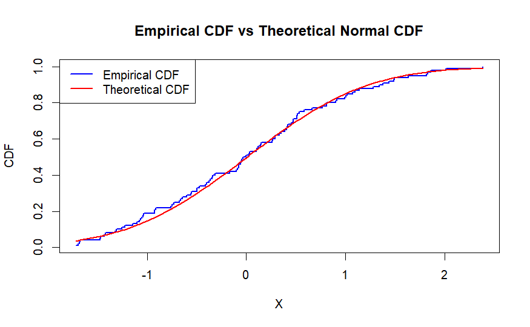

```r
legend("topleft", legend = c("Empirical CDF", "Theoretical CDF"),
       col = c("blue", "red"), lwd = 2)
```

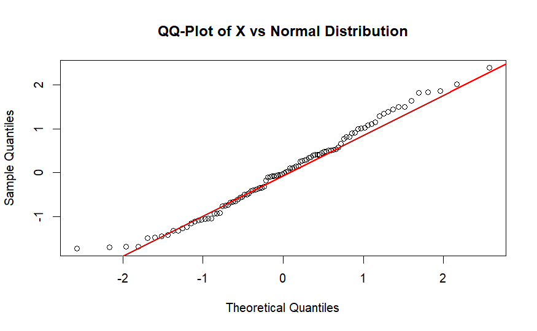

```r
qqnorm(X, main = "QQ-Plot of X vs Normal Distribution")
qqline(X, col = "red", lwd = 2)
```

**Comment:** In this part, we compare the empirical distribution of the sample X with the theoretical normal distribution having the mean and variance estimated from the data. We compute the maximum vertical difference between the empirical CDF and the theoretical CDF, and then apply the one-sample Kolmogorov–Smirnov test. The KS test is particularly powerful because it is nonparametric and sensitive to any type of deviation (shifts, scaling, skewness, or tail behavior), unlike tests that target specific parameters. The resulting KS statistic (D = 0.0516) is small, and the high p-value (0.9525) indicates that the sample is fully consistent with the assumed normal model.

##### b) Let`s check if our X are similar to exponential distribution with $\lambda = 1$

```r
x_sorted <- sort(abs(X))
Fn <- ecdf(abs(X))(x_sorted)
F0 <- pexp(x_sorted, rate = 1)
max_dif <- max(abs(Fn - F0))
cat("Max difference calculated by hand", max_dif, "\n")
```

```
Max difference calculated by hand 0.1355757
```

```r
ks.test(abs(X), "pexp", 1)
```

```
    Asymptotic one-sample Kolmogorov-Smirnov test

data:  abs(X)
D = 0.13558, p-value = 0.05064
alternative hypothesis: two-sided
```

```r
plot(x_sorted, Fn, type = "s", col = "blue", lwd = 2,
     xlab = "X", ylab = "CDF",
     main = "Absolute Empirical CDF vs Theoretical Exponential CDF")
lines(x_sorted, F0, col = "red", lwd = 2)
```

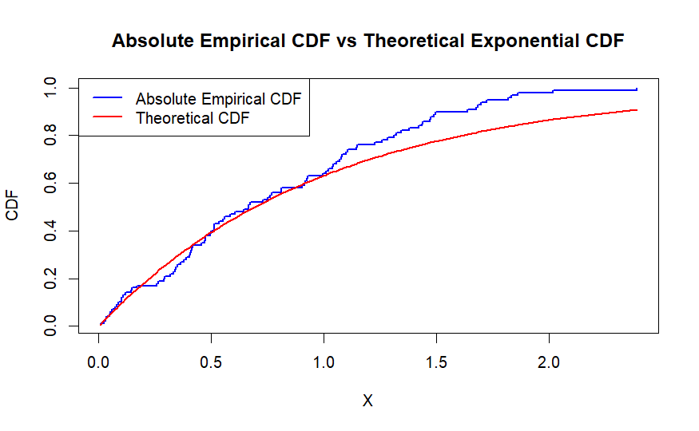

```r
legend("topleft", legend = c("Absolute Empirical CDF", "Theoretical CDF"),
       col = c("blue", "red"), lwd = 2)
```

[figure not shown]

```r
qqnorm(x_sorted, main = "QQ-Plot of Absolute X vs Exponential Distribution")
qqline(x_sorted, col = "red", lwd = 2)
```